# Data Visualization Project - Udacity - Prosper Loan Data Exploration

## Main features of this dataset

> Figre out what features can be used for credit default prediction and the features with the biggest correlations with prosper credit rating.

## What features will help support your investigation into your feature of interest?

> Before doing the check I believe that ProsperRating, Listing Category and EmploymentStatus will have the biggest correlations with default's probability and credit rating.

## Loan Status

> - Most of the loans in this dataset is either Current, Completed or Chargeoff.
> - Past due loans are split throughout several groups being over 120 days the category with less share
> - The risk of a loan is it's default. It seems that the loan dynamic is healthy due to the share of completed loans

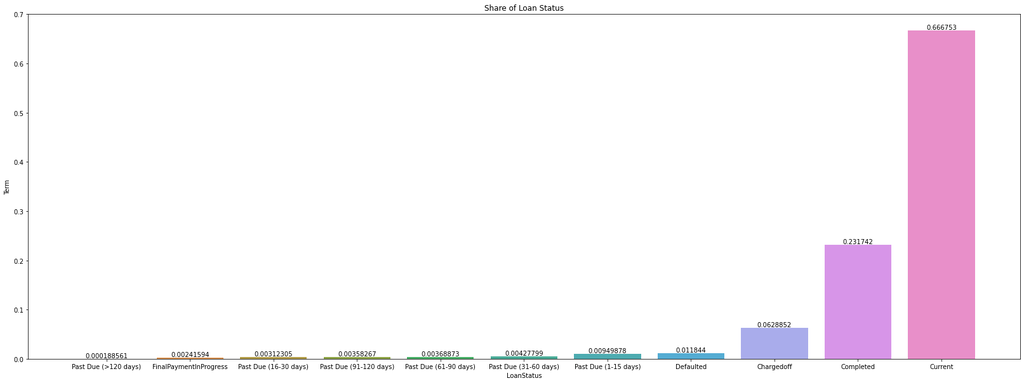

## Monthly Income

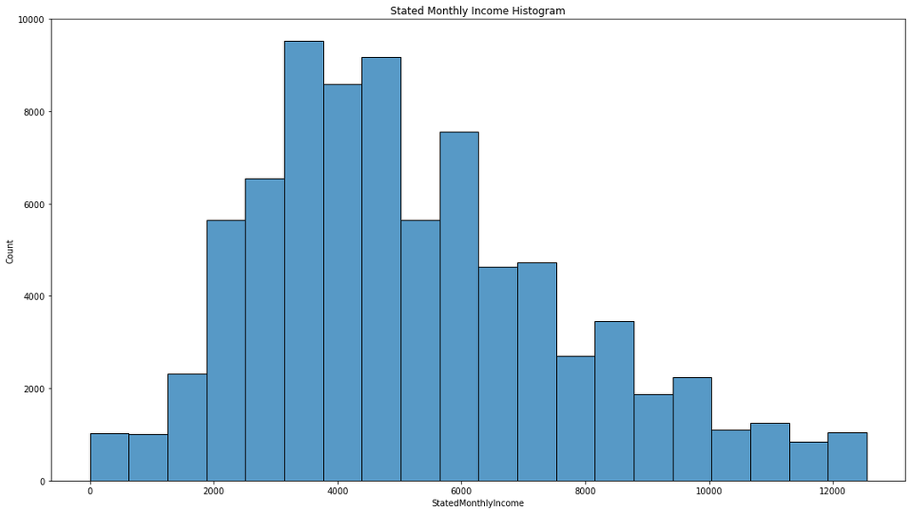

## Employment Status

- The biggest group is Employed followed by full-time, self-employed and Other.
- It seems that this column might be wrongly named. A very small part is considered Retired or not employed, and the rest of the categories are actually types of employments. Therefore despite for retired and not employed, all the others are Employed but with different kinds of employment.

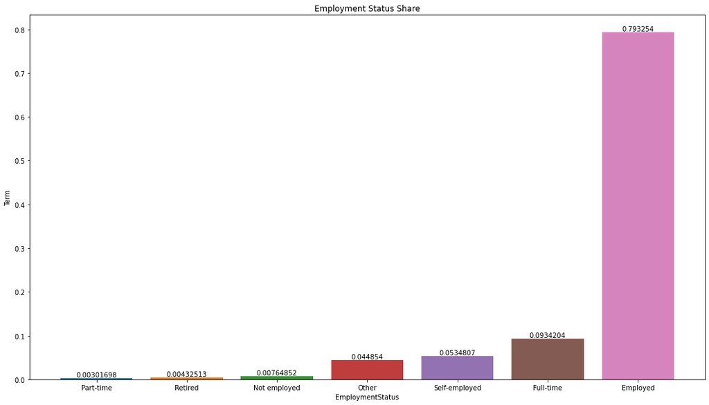

## Rating, Loan Status and Loan Amount

- Credits tends to be lower in Completed status along all prosper ratings
- Despite for A and AA ratings, the amount of credits for Active and Late tends to be similar

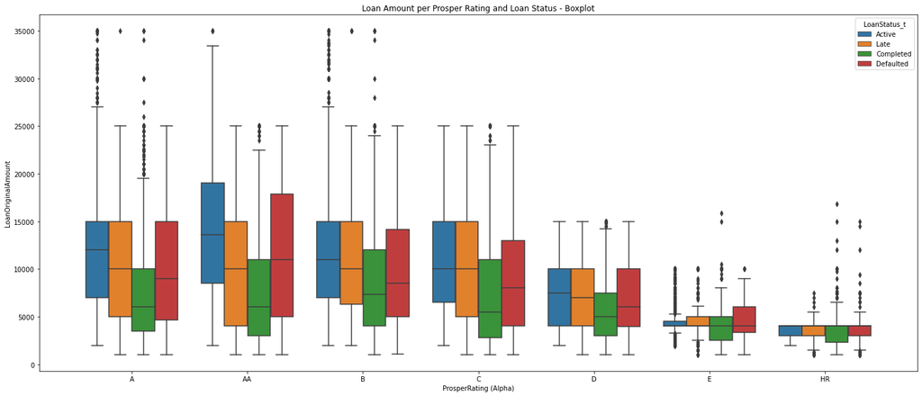

## Amount, Listing Category and Loan Status

- Credits of Active loan status seems to be the biggest along all listing categories
- Except for Active, all other loan status median seems to be similar throughout the listing categories

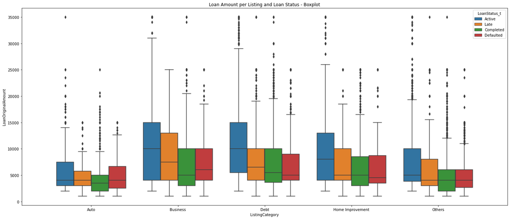

## Correlations

- Looking for this correlation table, there is not variable match where we have at least a slightly strong correlation (>50 or <-50)

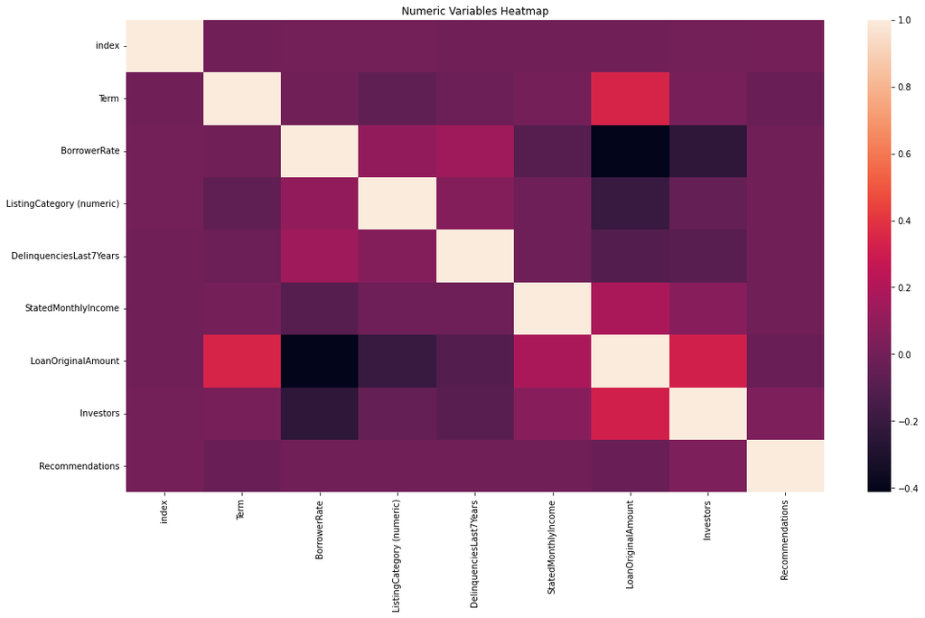

- After transforming our categories to numerical equivalents to use the correlation function, we still can't find a strong correlation among them.

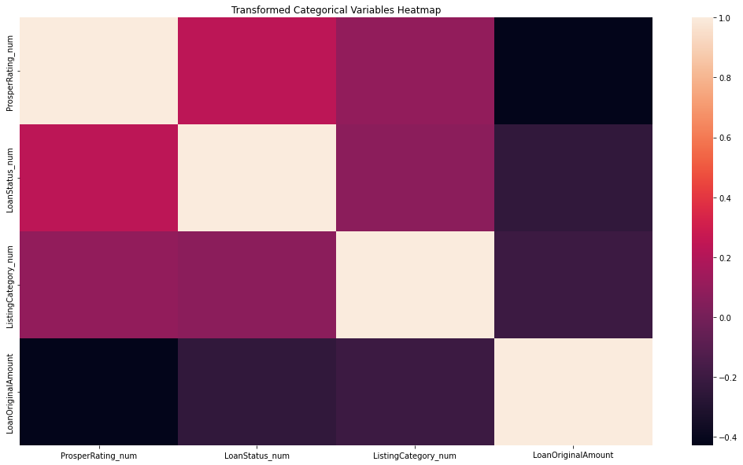

[output not shown]